# Correction 9 : *Naïve Bayes*

**Loïc Grobol** lgrobol@parisnanterre.fr

2021-10-11

```python
from IPython.display import display
```

```python
%pip install -U numpy scikit-learn
```

```python
%matplotlib inline
import numpy as np
import matplotlib.pyplot as plt
```

## Le dataset

```python
from sklearn.datasets import fetch_20newsgroups

categories = [
    "sci.crypt",
    "sci.electronics",
    "sci.med",
    "sci.space",
]

data_train = fetch_20newsgroups(
    subset='train',
    categories=categories,
    shuffle=True,
)

data_test = fetch_20newsgroups(
    subset='test',
    categories=categories,
    shuffle=True,
)
```

```python
print(data_train.DESCR)
```

```
.. _20newsgroups_dataset:

The 20 newsgroups text dataset
------------------------------

The 20 newsgroups dataset comprises around 18000 newsgroups posts on
20 topics split in two subsets: one for training (or development)
and the other one for testing (or for performance evaluation). The split
between the train and test set is based upon a messages posted before
and after a specific date.

This module contains two loaders. The first one,
:func:`sklearn.datasets.fetch_20newsgroups`,
returns a list of the raw texts that can be fed to text feature
extractors such as :class:`~sklearn.feature_extraction.text.CountVectorizer`
with custom parameters so as to extract feature vectors.
The second one, :func:`sklearn.datasets.fetch_20newsgroups_vectorized`,
returns ready-to-use features, i.e., it is not necessary to use a feature
extractor.

**Data Set Characteristics:**

    =================   ==========
    Classes                     20
    Samples total            18846
    Dimensionality               1
    Features                  text
    =================   ==========

Usage
~~~~~

The :func:`sklearn.datasets.fetch_20newsgroups` function is a data
fetching / caching functions that downloads the data archive from
the original `20 newsgroups website`_, extracts the archive contents
in the ``~/scikit_learn_data/20news_home`` folder and calls the
:func:`sklearn.datasets.load_files` on either the training or
testing set folder, or both of them::

  >>> from sklearn.datasets import fetch_20newsgroups
```

[output cut: 198 more lines]

```
    by setting ``remove=('headers', 'footers', 'quotes')``. The F-score will be
    lower because it is more realistic.
  - This text dataset contains data which may be inappropriate for certain NLP
    applications. An example is listed in the "Data Considerations" section
    above. The challenge with using current text datasets in NLP for tasks such
    as sentence completion, clustering, and other applications is that text
    that is culturally biased and inflammatory will propagate biases. This
    should be taken into consideration when using the dataset, reviewing the
    output, and the bias should be documented.

.. topic:: Examples

   * :ref:`sphx_glr_auto_examples_model_selection_grid_search_text_feature_extraction.py`

   * :ref:`sphx_glr_auto_examples_text_plot_document_classification_20newsgroups.py`
```

Bon, voyons ce que ce truc a concrètement dans le ventre

```python
print(len(data_train.data))
print(len(data_test.data))
```

```
2373
1579
```

```python
data_train.keys()
```

```
dict_keys(['data', 'filenames', 'target_names', 'target', 'DESCR'])
```

```python
type(data_train.data)
```

```
list
```

```python
data_train.data[0]
```

```
'From: al@escom.com (Al Donaldson)\nSubject: Re: Once tapped, your code is no good any more.\nReply-To: al@escom.COM (Al Donaldson)\nOrganization: ESCOM Corp., Oakton VA (USA)\nDistribution: na\nLines: 16\n\namolitor@nmsu.edu (Andrew Molitor) writes:\n>Yes, those evil guys in the FBI can probably, w…
```

```python
type(data_train.target)
```

```
numpy.ndarray
```

```python
data_train.target[0]
```

```
0
```

```python
data_train.target_names[0]
```

```
'sci.crypt'
```

Bon, c'est plutôt clair

## Sac de mots

On va commencer par transformer ces documents en sacs de mots. Pour ça on recycle

```python
import re
def poor_mans_tokenizer_and_normalizer(s):
    # Cette fois-ci on vire les nombres, les signes de ponctuation et les trucs bizarres
    return [w.lower() for w in re.split(r"\s|\W", s.strip()) if w and all(c.isalpha() for c in w)]
```

```python
from collections import Counter

def get_counts(doc):
    return Counter(poor_mans_tokenizer_and_normalizer(doc))

get_counts(data_train.data[0])
```

```
Counter({'from': 1,
         'al': 5,
         'escom': 3,
         'com': 2,
         'donaldson': 2,
         'subject': 1,
         're': 2,
         'once': 1,
         'tapped': 1,
         'your': 1,
         'code': 1,
         'is': 3,
         'no': 1,
         'good': 1,
         'any': 1,
         'more': 1,
         'reply': 1,
         'to': 4,
         'organization': 1,
         'corp': 1,
         'oakton': 1,
         'va': 1,
         'usa': 1,
         'distribution': 1,
         'na': 1,
         'lines': 1,
         'amolitor': 1,
         'nmsu': 1,
         'edu': 1,
         'andrew': 1,
         'molitor': 1,
         'writes': 1,
         'yes': 1,
         'those': 1,
         'evil': 2,
         'guys': 2,
         'in': 2,
         'the': 8,
         'fbi': 2,
         'can': 1,
```

[output cut: 53 more lines]

```
         'else': 1,
         'encryption': 1,
         'methods': 1,
         'unrelated': 1,
         'question': 1,
         'isn': 1,
         'term': 1,
         'clipper': 1,
         'as': 2,
         'neat': 1,
         'it': 1,
         'already': 1,
         'taken': 1,
         'by': 1,
         'intergraph': 1})
```

Maintenant, il faut le faire pour tous les docs 🏹

```python
bows = [get_counts(doc) for doc in data_train.data]
```

Et il nous faut récupérer tout le vocabulaire

```python
vocab = sorted(set().union(*bows)) # Pourquoi `sorted` à votre avis ?
len(vocab)
```

```
31116
```

On commence par faire un dict avec le vocabulaire

```python
w_to_i = {w: i for i, w in enumerate(vocab)}
```

```python
bow_array = np.zeros((len(bows), len(vocab)))
for i, bag in enumerate(bows):
    for w, c in bag.items():
        bow_array[i, w_to_i[w]] = c
bow_array
```

```
array([[1., 0., 0., ..., 0., 0., 0.],
       [2., 0., 0., ..., 0., 0., 0.],
       [3., 0., 0., ..., 0., 0., 0.],
       ...,
       [1., 0., 0., ..., 0., 0., 0.],
       [1., 0., 0., ..., 0., 0., 0.],
       [2., 0., 0., ..., 0., 0., 0.]])
```

## 🧙🏻 Exo 🧙🏻

> À vous de bosser maintenant. Écrivez

> 1. Une fonction qui prend en argument un tableau comme `data_train.target` et qui renvoie un tableau `class_probs` tel que `class_probs[c]` soit $P(c)$. On choisira le modèle de vraisemblance maximal, soit ici simplement celui qui utilise pour probabilités les fréquences empiriques $P(c) = \frac{\text{nombre d'occurrences de $c$}}{\text{taille de l'échantillon}}$.

```python
def get_class_probs(target):
    # Chaque élément est un numéro de classes, on va supposer que toutes les classes y sont
    # représentées
    # Les classes vont aller de 0 à n inclus, il y en a donc n+1
    n_classes = np.max(target) + 1
    # On va compter les éléments de chaque classe
    # On pourrait aussi faire avec `Counter()` mais comme on est parti avec des arrays, on va rester
    # avec des arrays
    counts = np.zeros(n_classes)
    for c in target:
        counts[c] += 1
    # On normalise par la somme pour avoir les fréquences empiriques
    total = counts.sum()
    # IL Y A UN BROADCAST ICI, REGARDEZ LES DIMENSIONS DES TABLEAUX
    return counts/total
```

On teste

```python
class_probs = get_class_probs(data_train.target)
class_probs
```

```
array([0.25073746, 0.24905183, 0.25031606, 0.24989465])
```

On visualise ?

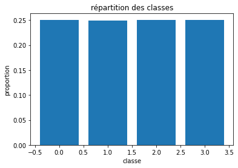

```python
plt.bar(np.arange(class_probs.shape[0]), class_probs)
plt.xlabel("classe")
plt.ylabel("proportion")
plt.title("répartition des classes")
plt.show()
```

Voilà un dataset bien équilibré

On aurait aussi pu faire directement

```python
def get_class_probs(target):
    return np.bincount(target)/target.size
get_class_probs(data_train.target)
```

```
array([0.25073746, 0.24905183, 0.25031606, 0.24989465])
```

> 2. Une fonction qui prend en argument un tableau comme `bow_array` et un tableau de classes `target` comme précédemment et renvoie un tableau `word_probs` tel que `word_probs[c,w]` soit $P(w|c)$. On utilise toujours le modèle de vraisemblance maximal mais avec un **lissage laplacien** : $P(w|c)=\frac{\text{nombre d'occurences de $w$ dans $c$} + 1}{\text{nombre de mots dans l'ensemble des documents de $c$}+\text{taille du vocabulaire}}$.

> N'hésitez pas à écrire des boucles, au moins pour commencer, avant de passer à du NumPy fancy.

On va commencer par le faire par étapes pour visualiser puis on mettra tout dans une fonction

On construit d'abord les comptes d'occurrences et on normalisera après

`bow_array` est de dimensions (nombre de documents, nombre de mots)

```python
bow_array.shape
```

```
(2373, 31116)
```

donc

```python
vocabulary_size = bow_array.shape[1]
```

```python
data_train.target
```

```
array([0, 1, 3, ..., 3, 3, 1])
```

```python
n_classes = np.max(data_train.target)+1
```

On va stocker les comptes dans un tableau de dimension `(nombre de classes, nombre de mots)`, on va d'abord le créer puis on le remplira dans une boucle.

```python
counts = np.zeros((n_classes, vocabulary_size))
counts
```

```
array([[0., 0., 0., ..., 0., 0., 0.],
       [0., 0., 0., ..., 0., 0., 0.],
       [0., 0., 0., ..., 0., 0., 0.],
       [0., 0., 0., ..., 0., 0., 0.]])
```

Ah, mais on a dit qu'on allait ajouter $1$ à tous les comptes pour lisser, donc il nous faut en fait

```python
counts = np.ones((n_classes, vocabulary_size))
counts
```

```
array([[1., 1., 1., ..., 1., 1., 1.],
       [1., 1., 1., ..., 1., 1., 1.],
       [1., 1., 1., ..., 1., 1., 1.],
       [1., 1., 1., ..., 1., 1., 1.]])
```

Maintenant on remplit avec une boucle : on itère sur les sacs de mots et on ajoute leurs comptes d'occurrences à la ligne qui correspond à leur classe. C'est assez facile : le nombre d'occurrence de chaque mot dans un doc, c'est juste sa ligne dans `bow_array`

```python
bow_array[0]
```

```
array([1., 0., 0., ..., 0., 0., 0.])
```

On va vouloir ajouter tous ces comptes à la ligne correspondant à sa classe (donc `data_train.targets[0]`) dans `counts`. On va pouvoir le faire directement avec la fonction d'addition des arrays

```python
bow_array[0] + counts[data_train.target[0]]
```

```
array([2., 1., 1., ..., 1., 1., 1.])
```

On fait ça pour tous les documents :

```python
for doc, c in zip(bow_array, data_train.target):
    counts[c] += doc
counts
```

```
array([[4.376e+03, 3.000e+00, 1.000e+00, ..., 1.000e+00, 1.000e+00,
        1.000e+00],
       [3.124e+03, 1.000e+00, 3.000e+00, ..., 1.000e+00, 4.000e+00,
        1.000e+00],
       [3.525e+03, 1.000e+00, 1.000e+00, ..., 2.000e+00, 1.000e+00,
        2.000e+00],
       [3.557e+03, 1.000e+00, 1.000e+00, ..., 1.000e+00, 1.000e+00,
        1.000e+00]])
```

Il reste à normaliser. Pour ça, il nous faut d'abord le nombre total de mots dans chaque classe. Par exemple pour la classe `0`

```python
np.sum(counts[0])
```

```
262248.0
```

On normalise avec ça les occurrences pour cette classe

```python
counts[0]/np.sum(counts[0])
```

```
array([1.66864952e-02, 1.14395534e-05, 3.81318447e-06, ...,
       3.81318447e-06, 3.81318447e-06, 3.81318447e-06])
```

On le fait pour tout le monde

```python
# On part d'un tableau vide : inutile de le préremplir puisqu'on va remplir chaque ligne à la main
word_probs = np.empty((n_classes, vocabulary_size))
# `enumerate` pour savoir quelle ligne remplir
for i, class_count in enumerate(counts):
    word_probs[i] = class_count/np.sum(class_count)
word_probs
```

```
array([[1.66864952e-02, 1.14395534e-05, 3.81318447e-06, ...,
        3.81318447e-06, 3.81318447e-06, 3.81318447e-06],
       [1.99128018e-02, 6.37413630e-06, 1.91224089e-05, ...,
        6.37413630e-06, 2.54965452e-05, 6.37413630e-06],
       [1.65949514e-02, 4.70778762e-06, 4.70778762e-06, ...,
        9.41557524e-06, 4.70778762e-06, 9.41557524e-06],
       [1.68684526e-02, 4.74232573e-06, 4.74232573e-06, ...,
        4.74232573e-06, 4.74232573e-06, 4.74232573e-06]])
```

Et voilà, on a fini !

On peut faire plus efficace avec des opérations sur les tableaux. On peut aussi passer cette section et y revenir plus tard !

On peut directement compter les totaux par classe avec le paramètre `axis` de `numpy.sum` qui dit sur quelle dimension on somme.

```python
total_per_class = np.sum(counts, axis=1)
total_per_class
```

```
array([262248., 156884., 212414., 210867.])
```

On a ensuite envie de diviser chaque ligne par sa somme en utilisant le broadcast

```python
counts/total_per_class
```

```
---------------------------------------------------------------------------
ValueError                                Traceback (most recent call last)
Input In [36], in <cell line: 1>()
----> 1 counts/total_per_class

ValueError: operands could not be broadcast together with shapes (4,31116) (4,)
```

Mais ça ne marche pas, parce que numpy ne veut pas ajouter de dimension pour nous. On peut s'en sortir de deux façons :

En ajoutant un axe à la somme

```python
display(total_per_class[:, np.newaxis].shape)
display(counts/total_per_class[:, np.newaxis])
```

```
(4, 1)
```

```
array([[1.66864952e-02, 1.14395534e-05, 3.81318447e-06, ...,
        3.81318447e-06, 3.81318447e-06, 3.81318447e-06],
       [1.99128018e-02, 6.37413630e-06, 1.91224089e-05, ...,
        6.37413630e-06, 2.54965452e-05, 6.37413630e-06],
       [1.65949514e-02, 4.70778762e-06, 4.70778762e-06, ...,
        9.41557524e-06, 4.70778762e-06, 9.41557524e-06],
       [1.68684526e-02, 4.74232573e-06, 4.74232573e-06, ...,
        4.74232573e-06, 4.74232573e-06, 4.74232573e-06]])
```

Ou en conservant l'axe $1$ lors de la somme

```python
total_per_class = np.sum(counts, axis=1, keepdims=True)
display(total_per_class.shape)
display(counts/total_per_class)
```

```
(4, 1)
```

```
array([[1.66864952e-02, 1.14395534e-05, 3.81318447e-06, ...,
        3.81318447e-06, 3.81318447e-06, 3.81318447e-06],
       [1.99128018e-02, 6.37413630e-06, 1.91224089e-05, ...,
        6.37413630e-06, 2.54965452e-05, 6.37413630e-06],
       [1.65949514e-02, 4.70778762e-06, 4.70778762e-06, ...,
        9.41557524e-06, 4.70778762e-06, 9.41557524e-06],
       [1.68684526e-02, 4.74232573e-06, 4.74232573e-06, ...,
        4.74232573e-06, 4.74232573e-06, 4.74232573e-06]])
```

On pourrait aussi remplacer la première boucle par [`np.put_along_axis`](https://numpy.org/doc/stable/reference/generated/numpy.put_along_axis), mais les boucles, c'est pas si pire.

On met tout dans une fonction

```python
def get_word_probs(bows, target):
    counts = np.ones((np.max(target)+1, bows.shape[1]))
    for doc, c in zip(bows, target):
        counts[c] += doc
    total_per_class = np.sum(counts, axis=1, keepdims=True)
    return counts/total_per_class
get_word_probs(bow_array, data_train.target)
```

```
array([[1.66864952e-02, 1.14395534e-05, 3.81318447e-06, ...,
        3.81318447e-06, 3.81318447e-06, 3.81318447e-06],
       [1.99128018e-02, 6.37413630e-06, 1.91224089e-05, ...,
        6.37413630e-06, 2.54965452e-05, 6.37413630e-06],
       [1.65949514e-02, 4.70778762e-06, 4.70778762e-06, ...,
        9.41557524e-06, 4.70778762e-06, 9.41557524e-06],
       [1.68684526e-02, 4.74232573e-06, 4.74232573e-06, ...,
        4.74232573e-06, 4.74232573e-06, 4.74232573e-06]])
```

Voilà, on a un modèle de classification *Naïve Bayes* 👏🏻

> 3. Une fonction qui prend en argument un document et renvoie la classe la plus probable notre modèle. Pensez à travailler en log-probabilités

On va s'inspirer de l'algo 4.2 de *Speech and Language Processing* en le compactifiant un peu.

D'abord on calcule les log-paramètres du modèle

```python
log_prior = np.log(get_class_probs(data_train.target))
log_likelihood = np.log(get_word_probs(bow_array, data_train.target))
display(log_prior)
display(log_likelihood)
```

```
array([-1.38334885, -1.39009424, -1.38503094, -1.38671586])
```

```
array([[ -4.09315556, -11.37843361, -12.4770459 , ..., -12.4770459 ,
        -12.4770459 , -12.4770459 ],
       [ -3.91639245, -11.96326196, -10.86464967, ..., -11.96326196,
        -10.5769676 , -11.96326196],
       [ -4.09865676, -12.26629248, -12.26629248, ..., -11.5731453 ,
        -12.26629248, -11.5731453 ],
       [ -4.08231011, -12.25898288, -12.25898288, ..., -12.25898288,
        -12.25898288, -12.25898288]])
```

Et on se rappelle qu'on a déjà le vocabulaire dans `w_to_i`

Ensuite on les exploite

```python
def predict_class(doc):
    # D'abord on récupère sa représentation en sacs de mots
    bow_dict = get_counts(doc)
    bow = np.zeros(len(w_to_i))
    for w, c in bow_dict.items():
        # On ne garde que les mots connus (on peut économiser un lookup, à votre avis comment ?)
        if w not in w_to_i:
            continue
        bow[w_to_i[w]] = c
    class_likelihoods = np.empty(n_classes)
    for i, (class_log_prior, class_log_likelihood) in enumerate(zip(log_prior, log_likelihood)):
        acc = 0.0
        for word_count, word_log_likelihood in zip(bow, class_log_likelihood):
            acc += word_count*word_log_likelihood
        class_likelihoods[i] = acc + class_log_prior
    return np.argmax(class_likelihoods)
```

```python
print(data_train.data[0][:300])
predicted = predict_class(data_train.data[0])
print(f"La classe prédite pour le premier document est {predicted}, soit {data_train.target_names[predicted]}")
print(f"La classe correcte était {data_train.target[0]}, soit {data_train.target_names[data_train.target[0]]}")
```

```
From: al@escom.com (Al Donaldson)
Subject: Re: Once tapped, your code is no good any more.
Reply-To: al@escom.COM (Al Donaldson)
Organization: ESCOM Corp., Oakton VA (USA)
Distribution: na
Lines: 16

amolitor@nmsu.edu (Andrew Molitor) writes:
>Yes, those evil guys in the FBI can probably, with some

La classe prédite pour le premier document est 0, soit sci.crypt
La classe correcte était 0, soit sci.crypt
```

Ou en plus rapide et compact avec un [produit scalaire](https://numpy.org/doc/stable/reference/generated/numpy.inner) vecteur-vecteur

```python
def predict_class(doc):
    bow_dict = get_counts(doc)
    bow = np.zeros(len(w_to_i))
    for w, c in bow_dict.items():
        if w not in w_to_i:
            continue
        bow[w_to_i[w]] = c
    class_likelihoods = np.empty(n_classes)
    for i, (class_log_prior, class_log_likelihood) in enumerate(zip(log_prior, log_likelihood)):
        class_likelihoods[i, ...] = class_log_prior + np.inner(bow, class_log_likelihood)
    return np.argmax(class_likelihoods)
```

Ou encore plus rapide et compact avec une [multiplication matrice-vecteur](https://numpy.org/doc/stable/reference/generated/numpy.matmul)

```python
def predict_class(doc):
    bow_dict = get_counts(doc)
    bow = np.zeros(len(w_to_i))
    for w, c in bow_dict.items():
        if w not in w_to_i:
            continue
        bow[w_to_i[w]] = c
    class_likelihoods = np.matmul(log_likelihood, bow) + log_prior
    return np.argmax(class_likelihoods)
```

Si vous voulez vous motiver à mieux apprendre numpy, je vous recommande de chronométrer les temps d'exécution de la suite avec les différentes versions de cette fonction.

> Vous pouvez maintenant évaluer le modèle en calculant son exactitude sur l'ensemble de test.

On va déjà le faire sur l'ensemble de train

```python
predictions = np.array([predict_class(text) for text in data_train.data])
display(predictions)
correct = predictions == data_train.target
display(correct)
print(f"Il y a {correct.sum()} exemples bien classés parmis {correct.size}, soit {correct.sum()/correct.size:.2%} d'exactitude")
```

```
array([0, 1, 3, ..., 3, 3, 1])
```

```
array([ True,  True,  True, ...,  True,  True,  True])
```

```
Il y a 2369 exemples bien classés parmis 2373, soit 99.83% d'exactitude
```

Plutôt encourageant ! on va écrire une fonction pour le faire sur n'importe quel ensemble de textes

```python
def evaluate(documents, target):
    predictions = np.array([predict_class(text) for text in documents])
    correct = predictions == target
    return correct.sum()/correct.size
```

```python
evaluate(data_test.data, data_test.target)
```

```
0.9392020265991133
```

> 4. Un script qui entraîne le modèle et le sauvegarde (sous la forme qui vous paraît la plus appropriée) et un qui charge le modèle et prédit la classe de chacun des documents d'un corpus.

> Courage, c'est pour votre bien. Si vous vous ennuyez ça peut être le bon moment pour découvrir [click](https://click.palletsprojects.com/en/8.0.x/).

Voir `nb_script.py`